# Biodiversity analysis

T. Griffin

2024-04-29

## set the seed to keep things consistent

```r
set.seed(02262000)
```

## Goals

Calculate the Hill Diversity of the samples. Evaluate the rarefaction curves. Evaluate the Diversity values. Makes notes of specific samples and their seq depth.

I’m thinking that the burn year should impact species richness and influence more dominant taxa to appear with more prescribed burning.

## Load all the libraries

```r
library(tidyverse)
library(devtools)
library(patchwork)
library(iNEXT)
library(phyloseq)

#add in the colors
horizon_colors <- c(
"A horizon" = "pink",
"B horizon" = "green",
"E horizon" = "orange")

burn_year_colors <-  c(
  "1" = "blue",
  "2" = "yellow",
  "4" = "red",
  "CH" = "purple")
```

## load in the raw phyloseq object

```r
load("/local/workdir/tag92/git_repos/comp_micro_proj/preprocessing_phyloseq/Data/NEW_raw_physeq.RData")
NEW_raw_physeq
```

```
## phyloseq-class experiment-level object
## otu_table()   OTU Table:         [ 32759 taxa and 72 samples ]
## sample_data() Sample Data:       [ 72 samples by 47 sample variables ]
## tax_table()   Taxonomy Table:    [ 32759 taxa by 9 taxonomic ranks ]
```

```r
min(sample_sums(NEW_raw_physeq))
```

```
## [1] 10464
```

```r
metadata_df <-
  NEW_raw_physeq %>%
  sample_data() %>%
  data.frame()

head(metadata_df)
```

```
##                   names Assay.Type AvgSpotLen     Bases  BioProject
## SRR19625066 SRR19625066   AMPLICON        602  46680886 PRJNA847616
## SRR19625067 SRR19625067   AMPLICON        602  44439038 PRJNA847616
## SRR19625068 SRR19625068   AMPLICON        602 149508506 PRJNA847616
## SRR19625069 SRR19625069   AMPLICON        602 102026358 PRJNA847616
## SRR19625070 SRR19625070   AMPLICON        602 115217382 PRJNA847616
## SRR19625071 SRR19625071   AMPLICON        602  79318918 PRJNA847616
##                BioSample                        BioSampleModel    Bytes
## SRR19625066 SAMN28946506 MIMARKS.survey,MIGS/MIMS/MIMARKS.soil 26456518
## SRR19625067 SAMN28946505 MIMARKS.survey,MIGS/MIMS/MIMARKS.soil 25292261
## SRR19625068 SAMN28946568 MIMARKS.survey,MIGS/MIMS/MIMARKS.soil 85309504
## SRR19625069 SAMN28946567 MIMARKS.survey,MIGS/MIMS/MIMARKS.soil 58257097
## SRR19625070 SAMN28946504 MIMARKS.survey,MIGS/MIMS/MIMARKS.soil 64986000
## SRR19625071 SAMN28946566 MIMARKS.survey,MIGS/MIMS/MIMARKS.soil 44753728
##                     Center.Name Collection_Date Consent DATASTORE.filetype
## SRR19625066 UNIVERSITY OF IDAHO          1/1/18  public   sra,run.zq,fastq
## SRR19625067 UNIVERSITY OF IDAHO          1/1/18  public   run.zq,fastq,sra
## SRR19625068 UNIVERSITY OF IDAHO          1/1/18  public   run.zq,sra,fastq
## SRR19625069 UNIVERSITY OF IDAHO          1/1/18  public   sra,run.zq,fastq
## SRR19625070 UNIVERSITY OF IDAHO          1/1/18  public   run.zq,fastq,sra
## SRR19625071 UNIVERSITY OF IDAHO          1/1/18  public   run.zq,fastq,sra
##             DATASTORE.provider               DATASTORE.region Depth elev
## SRR19625066         gs,s3,ncbi s3.us-east-1,gs.US,ncbi.public  43cm  45m
## SRR19625067         ncbi,gs,s3 ncbi.public,s3.us-east-1,gs.US  58cm  45m
## SRR19625068         gs,ncbi,s3 gs.US,ncbi.public,s3.us-east-1  28cm  45m
## SRR19625069         ncbi,s3,gs s3.us-east-1,ncbi.public,gs.US  36cm  45m
## SRR19625070         ncbi,s3,gs gs.US,s3.us-east-1,ncbi.public  11cm  45m
## SRR19625071         s3,ncbi,gs s3.us-east-1,ncbi.public,gs.US   8cm  45m
##             env_broad_scale env_local_scale                  env_medium
## SRR19625066   ENVO_01000174   ENVO_01001582 ENVO_00005746 | PCO_1000004
## SRR19625067   ENVO_01000174   ENVO_01001582 ENVO_00005746 | PCO_1000004
## SRR19625068   ENVO_01000174   ENVO_01001582 ENVO_00005746 | PCO_1000004
## SRR19625069   ENVO_01000174   ENVO_01001582 ENVO_00005746 | PCO_1000004
## SRR19625070   ENVO_01000174   ENVO_01001582 ENVO_00005746 | PCO_1000004
## SRR19625071   ENVO_01000174   ENVO_01001582 ENVO_00005746 | PCO_1000004
##              Experiment geo_loc_name_country geo_loc_name_country_continent
## SRR19625066 SRX15675757                  USA                  North America
## SRR19625067 SRX15675756                  USA                  North America
## SRR19625068 SRX15675755                  USA                  North America
## SRR19625069 SRX15675754                  USA                  North America
```

[output cut: 22 more lines]

```
## SRR19625071 soil metagenome ILLUMINA 6/11/22 20:00        NO 6/12/22 18:38
##             version    Sample.Name burn_year Plot SRA.Study  input filtered
## SRR19625066       1  1C_E_FLBACPRE         1    C SRP379614  77543    61419
## SRR19625067       1  1C_B_FLBACPRE         1    C SRP379614  73819    57574
## SRR19625068       1 CHF_E_FLBACPRE        CH    F SRP379614 248353   192777
## SRR19625069       1 CHF_B_FLBACPRE        CH    F SRP379614 169479   130973
## SRR19625070       1  1C_A_FLBACPRE         1    C SRP379614 191391   152705
## SRR19625071       1 CHF_A_FLBACPRE        CH    F SRP379614 131759   104718
##             denoisedF denoisedR merged nochim perc_reads_retained
## SRR19625066     55573     57209  31982  28542            36.80796
## SRR19625067     52926     53977  33121  28274            38.30179
## SRR19625068    182661    184950 125125  94925            38.22181
## SRR19625069    123526    124844  80994  60919            35.94487
## SRR19625070    143849    145815  98452  80835            42.23553
## SRR19625071     98311    100012  66034  53637            40.70841
```

## Running iNEXT for diversity calculations

```r
iNEXT_input_df <-
  NEW_raw_physeq %>%
  otu_table() %>%
  data.frame()

dim(iNEXT_input_df)
```

```
## [1] 32759    72
```

```r
#this will actually run inext
#iNEXT_data <- iNEXT(iNEXT_input_df,
                   #q = c(0,1,2), datatype = "abundance")

#save(iNEXT_data, file = "./biodiversity-analysis/new_iNEXT_data.RData")
```

## Evaluating diversity

```r
load("/local/workdir/tag92/git_repos/comp_micro_proj/biodiversity-analysis/new_iNEXT_data.RData")
str(iNEXT_data)
```

```
## List of 3
##  $ DataInfo:'data.frame':    72 obs. of  14 variables:
##   ..$ Assemblage: chr [1:72] "SRR19625066" "SRR19625067" "SRR19625068" "SRR19625069" ...
##   ..$ n         : num [1:72] 28534 28274 94876 60885 80721 ...
##   ..$ S.obs     : num [1:72] 710 770 2593 1735 1924 ...
##   ..$ SC        : num [1:72] 1 1 1 1 1 ...
##   ..$ f1        : num [1:72] 4 2 9 6 15 3 7 0 2 5 ...
##   ..$ f2        : num [1:72] 3 4 7 11 18 7 8 7 6 4 ...
##   ..$ f3        : num [1:72] 3 2 13 12 20 7 11 6 8 5 ...
##   ..$ f4        : num [1:72] 10 5 22 9 17 6 7 12 10 7 ...
##   ..$ f5        : num [1:72] 6 1 24 16 21 9 19 6 2 19 ...
##   ..$ f6        : num [1:72] 6 10 22 20 20 12 14 10 8 11 ...
##   ..$ f7        : num [1:72] 11 10 26 20 25 8 32 11 3 20 ...
##   ..$ f8        : num [1:72] 9 15 41 16 21 15 13 9 15 19 ...
##   ..$ f9        : num [1:72] 15 12 36 21 27 23 16 13 13 21 ...
##   ..$ f10       : num [1:72] 12 17 47 26 26 25 15 13 14 16 ...
##  $ iNextEst:List of 2
##   ..$ size_based    :'data.frame':   8640 obs. of  10 variables:
##   .. ..$ Assemblage: chr [1:8640] "SRR19625066" "SRR19625066" "SRR19625066" "SRR19625066" ...
##   .. ..$ m         : num [1:8640] 1 1586 3171 4756 6341 ...
##   .. ..$ Method    : chr [1:8640] "Rarefaction" "Rarefaction" "Rarefaction" "Rarefaction" ...
##   .. ..$ Order.q   : num [1:8640] 0 0 0 0 0 0 0 0 0 0 ...
##   .. ..$ qD        : num [1:8640] 1 552 644 674 688 ...
##   .. ..$ qD.LCL    : num [1:8640] 1 550 641 672 685 ...
##   .. ..$ qD.UCL    : num [1:8640] 1 554 646 677 691 ...
##   .. ..$ SC        : num [1:8640] 0.00209 0.89404 0.96996 0.98773 0.99389 ...
##   .. ..$ SC.LCL    : num [1:8640] 0.00207 0.89294 0.96929 0.98727 0.99355 ...
##   .. ..$ SC.UCL    : num [1:8640] 0.00212 0.89514 0.97063 0.98819 0.99423 ...
##   ..$ coverage_based:'data.frame':   8325 obs. of  8 variables:
##   .. ..$ Assemblage: chr [1:8325] "SRR19625066" "SRR19625066" "SRR19625066" "SRR19625066" ...
##   .. ..$ SC        : num [1:8325] 0.00209 0.89404 0.96996 0.98773 0.99389 ...
##   .. ..$ m         : num [1:8325] 1 1586 3171 4756 6341 ...
##   .. ..$ Method    : chr [1:8325] "Rarefaction" "Rarefaction" "Rarefaction" "Rarefaction" ...
##   .. ..$ Order.q   : num [1:8325] 0 0 0 0 0 0 0 0 0 0 ...
##   .. ..$ qD        : num [1:8325] 1 552 644 674 688 ...
##   .. ..$ qD.LCL    : num [1:8325] 1 549 640 671 685 ...
##   .. ..$ qD.UCL    : num [1:8325] 1 555 647 678 691 ...
##  $ AsyEst  :'data.frame':    216 obs. of  7 variables:
##   ..$ Assemblage: chr [1:216] "SRR19625066" "SRR19625066" "SRR19625066" "SRR19625067" ...
##   ..$ Diversity : chr [1:216] "Species richness" "Shannon diversity" "Simpson diversity" "Species richness" ...
##   ..$ Observed  : num [1:216] 710 559 470 770 613 ...
##   ..$ Estimator : num [1:216] 713 566 478 770 622 ...
##   ..$ s.e.      : num [1:216] 3.82 1.84 2.82 3.59 2.28 ...
##   ..$ LCL       : num [1:216] 710 562 472 770 617 ...
##   ..$ UCL       : num [1:216] 720 570 483 778 626 ...
##  - attr(*, "class")= chr "iNEXT"
```

```r
typeof(iNEXT_data)
```

```
## [1] "list"
```

## Plot Diversity

```r
# Prepare Colors
color_df <-
  iNEXT_input_df %>%
  colnames() %>%
  data.frame()

head(color_df)
```

```
##             .
## 1 SRR19625066
## 2 SRR19625067
## 3 SRR19625068
## 4 SRR19625069
## 5 SRR19625070
## 6 SRR19625071
```

```r
# Rename the column
colnames(color_df)[1] <- "names"

head(color_df)
```

```
##         names
## 1 SRR19625066
## 2 SRR19625067
## 3 SRR19625068
## 4 SRR19625069
## 5 SRR19625070
## 6 SRR19625071
```

```r
# Make a helper dataframe for plotting with colors
iNEXT_color_df <-
  color_df %>%
  # Fix the names for merging
  mutate(names = gsub(names, pattern = "[.]", replace = "-"),
         names = gsub(names, pattern = "X",  replace = "")) %>%
  # Merge with metadata
  left_join(metadata_df, by = "names") %>%
  # Merge with colors for plotting with ggiNEXT
  left_join(data.frame(horizon_colors = horizon_colors,
            horizon = names(horizon_colors)),
            by = "horizon")
```

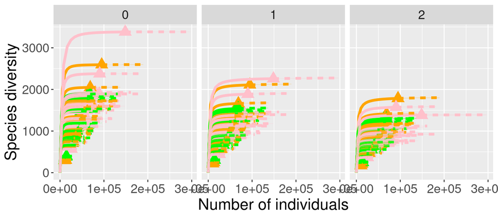

```r
#Plot rarefaction!
#rarefaction/extrapolation curve, type = 1

#order Q, when it is zero= it equals the richness/total number of taxa, when it equals 1, it equals the exponentialShannon/ number of common taxa, when it is 2, this is the inverse simpson/number of dominant taxa

ggiNEXT(iNEXT_data, type = 1, facet.var = "Order.q") +
  facet_wrap(~Order.q, scales = "fixed") +
  scale_color_manual(values = iNEXT_color_df$horizon_colors, guide = FALSE) +
  scale_fill_manual(values = iNEXT_color_df$horizon_colors, guide = FALSE) +
  scale_shape_manual(values = base::rep(17, nsamples(NEW_raw_physeq)),
                     guide = FALSE) +
  theme(legend.position = "none")
```

there are outliers with the A horizon, but each horizon seems to have similar richness. As expected, graphs plateu sooner as abundance is weighted more.

## Manually plot diversity

```r
iNEXT_manual_df <-
  iNEXT_data$iNextEst$size_based %>%
  dplyr::rename(names = Assemblage) %>%
  # Fix the samples names
  mutate(names = gsub(names, pattern = "[.]", replace = "-"),
         names = gsub(names, pattern = "X", replace = "")) %>%
  # join with metadata
  left_join(., metadata_df, by = "names") %>%
  # Add colors to data frame
  left_join(., data.frame(horizon_colors = horizon_colors,
                          horizon = names(horizon_colors)),
            by = "horizon")
# Inspect
dim(iNEXT_manual_df)
```

```
## [1] 8640   57
```

```r
#8640, 57

str(iNEXT_manual_df)
```

```
## 'data.frame':    8640 obs. of  57 variables:
##  $ names                         : chr  "SRR19625066" "SRR19625066" "SRR19625066" "SRR19625066" ...
##  $ m                             : num  1 1586 3171 4756 6341 ...
##  $ Method                        : chr  "Rarefaction" "Rarefaction" "Rarefaction" "Rarefaction" ...
##  $ Order.q                       : num  0 0 0 0 0 0 0 0 0 0 ...
##  $ qD                            : num  1 552 644 674 688 ...
##  $ qD.LCL                        : num  1 550 641 672 685 ...
##  $ qD.UCL                        : num  1 554 646 677 691 ...
##  $ SC                            : num  0.00209 0.89404 0.96996 0.98773 0.99389 ...
##  $ SC.LCL                        : num  0.00207 0.89294 0.96929 0.98727 0.99355 ...
##  $ SC.UCL                        : num  0.00212 0.89514 0.97063 0.98819 0.99423 ...
##  $ Assay.Type                    : chr  "AMPLICON" "AMPLICON" "AMPLICON" "AMPLICON" ...
##  $ AvgSpotLen                    : int  602 602 602 602 602 602 602 602 602 602 ...
##  $ Bases                         : int  46680886 46680886 46680886 46680886 46680886 46680886 46680886 46680886 46680886 46680886 ...
##  $ BioProject                    : chr  "PRJNA847616" "PRJNA847616" "PRJNA847616" "PRJNA847616" ...
```

[output cut: 43 more lines]

## Plot rarefaction curve for horizon

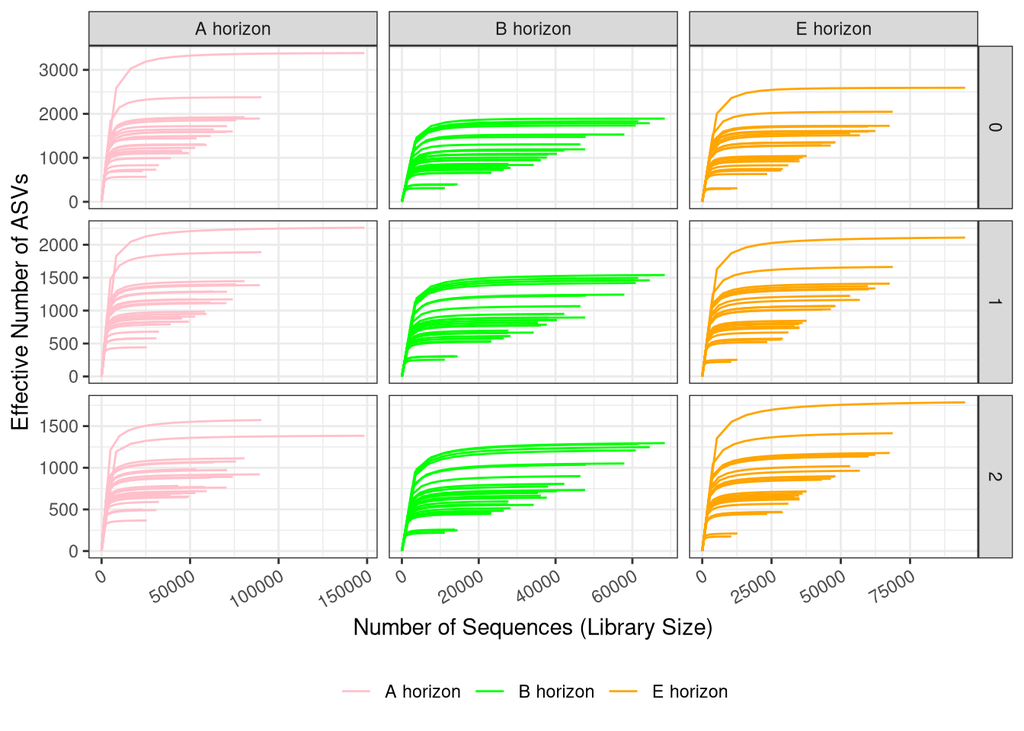

```r
iNEXT_manual_df %>%
  # Filter out rows that are calcaulted by rarefaction from iNEXT
  dplyr::filter(Method == "Rarefaction") %>%
  # Now, let's draw the plot, be sure to group by the samples if using geom_line!
  ggplot(aes(x = m, y= qD, color = horizon, group = names)) +
  geom_line() +
  # Facet with the station to see the samples better
  facet_grid(Order.q~horizon, scales = "free") +
  scale_color_manual(values = horizon_colors) +
  labs(x = "Number of Sequences (Library Size)",
       y = "Effective Number of ASVs") +
  theme_bw() +
  #guides(color = guide_legend(nrow = 2, byrow = TRUE)) +
  theme(legend.position = "bottom",
        axis.text.x = element_text(angle = 30, vjust = 1, hjust = 1),
        legend.title = element_blank())
```

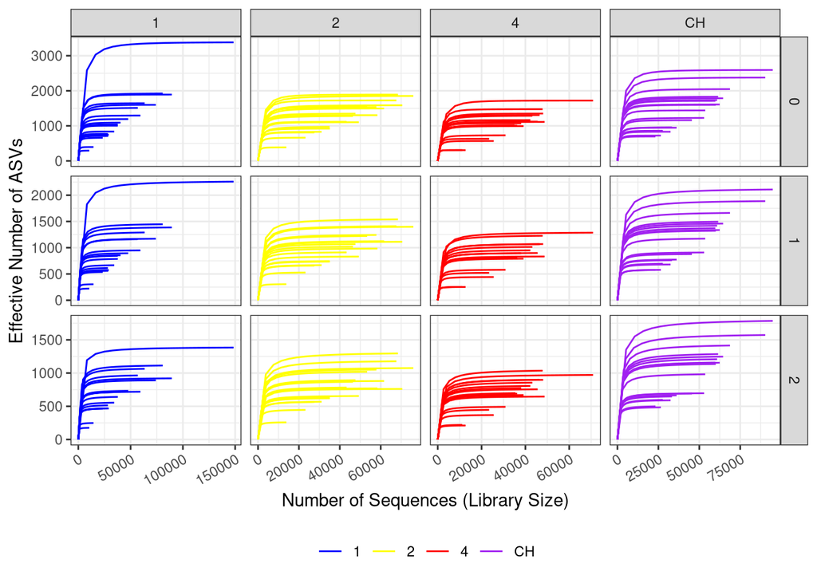

```r
iNEXT_manual_df %>%
  # Filter out rows that are calcaulted by rarefaction from iNEXT
  dplyr::filter(Method == "Rarefaction") %>%
  # Now, let's draw the plot, be sure to group by the samples if using geom_line!
  ggplot(aes(x = m, y= qD, color = burn_year, group = names)) +
  geom_line() +
  # Facet with the station to see the samples better
  facet_grid(Order.q~burn_year, scales = "free") +
  scale_color_manual(values = burn_year_colors) +
  labs(x = "Number of Sequences (Library Size)",
       y = "Effective Number of ASVs") +
  theme_bw() +
  #guides(color = guide_legend(nrow = 2, byrow = TRUE)) +
  theme(legend.position = "bottom",
        axis.text.x = element_text(angle = 30, vjust = 1, hjust = 1),
        legend.title = element_blank())
```

## Making the boxplots

```r
horizon_names <- c("A Horizon", "E Horizon","B Horizon")

names(horizon_names) <- c("A Horizon", "E Horizon","B Horizon")

# Make a dataframe
obs_div_df <-
  iNEXT_manual_df %>%
  dplyr::filter(Method == "Observed") %>%
  left_join(data.frame(horizon_names = horizon_names,
                       horizon = names(horizon_names)),
                       by = "horizon")

# Check it
head(obs_div_df)
```

```
##         names     m   Method Order.q       qD   qD.LCL   qD.UCL        SC
## 1 SRR19625066 28534 Observed       0 710.0000 706.7194 713.2806 0.9998598
## 2 SRR19625066 28534 Observed       1 558.9683 555.3946 562.5420 0.9998598
## 3 SRR19625066 28534 Observed       2 469.7097 464.7943 474.6251 0.9998598
## 4 SRR19625067 28274 Observed       0 770.0000 768.0087 771.9913 0.9999293
## 5 SRR19625067 28274 Observed       1 613.0414 608.8281 617.2548 0.9999293
## 6 SRR19625067 28274 Observed       2 513.8368 507.6696 520.0040 0.9999293
##      SC.LCL    SC.UCL Assay.Type AvgSpotLen    Bases  BioProject    BioSample
## 1 0.9997239 0.9999958   AMPLICON        602 46680886 PRJNA847616 SAMN28946506
## 2 0.9997239 0.9999958   AMPLICON        602 46680886 PRJNA847616 SAMN28946506
## 3 0.9997239 0.9999958   AMPLICON        602 46680886 PRJNA847616 SAMN28946506
## 4 0.9998208 1.0000000   AMPLICON        602 44439038 PRJNA847616 SAMN28946505
## 5 0.9998208 1.0000000   AMPLICON        602 44439038 PRJNA847616 SAMN28946505
## 6 0.9998208 1.0000000   AMPLICON        602 44439038 PRJNA847616 SAMN28946505
##                          BioSampleModel    Bytes         Center.Name
```

[output cut: 62 more lines]

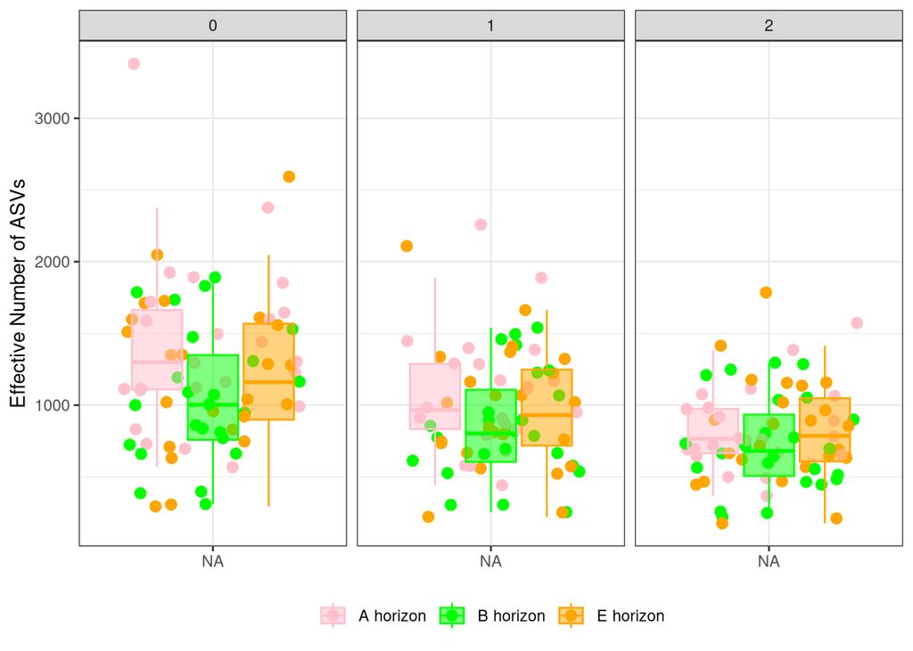

```r
#make a boxplot by the horizon
obs_div_df %>%
  ggplot(aes(x = horizon_names, y = qD, fill = horizon, color = horizon)) +
  facet_wrap(~Order.q, scales = "fixed") +
  geom_jitter(size = 2.5) +
  geom_boxplot(alpha = 0.5, outlier.shape = NA) +
  scale_color_manual(values = horizon_colors) +
  scale_fill_manual(values = horizon_colors) +
  labs(y = "Effective Number of ASVs") +
  theme_bw() +
  theme(legend.position = "bottom",
        axis.title.x = element_blank(),
        legend.title = element_blank())
```

```r
burnyears <- c("CH", "1", "2", "4")

names(burnyears) <- c("CH", "1", "2", "4")

# do the same thing for burn year
by_obs_div_df <-
  iNEXT_manual_df %>%
  dplyr::filter(Method == "Observed") %>%
  left_join(data.frame(burnyears = burnyears,
                       burn_year = names(burnyears)),
                       by = "burn_year")

# Check it
head(by_obs_div_df)
```

```
##         names     m   Method Order.q       qD   qD.LCL   qD.UCL        SC
## 1 SRR19625066 28534 Observed       0 710.0000 706.7194 713.2806 0.9998598
## 2 SRR19625066 28534 Observed       1 558.9683 555.3946 562.5420 0.9998598
## 3 SRR19625066 28534 Observed       2 469.7097 464.7943 474.6251 0.9998598
## 4 SRR19625067 28274 Observed       0 770.0000 768.0087 771.9913 0.9999293
## 5 SRR19625067 28274 Observed       1 613.0414 608.8281 617.2548 0.9999293
## 6 SRR19625067 28274 Observed       2 513.8368 507.6696 520.0040 0.9999293
##      SC.LCL    SC.UCL Assay.Type AvgSpotLen    Bases  BioProject    BioSample
## 1 0.9997239 0.9999958   AMPLICON        602 46680886 PRJNA847616 SAMN28946506
## 2 0.9997239 0.9999958   AMPLICON        602 46680886 PRJNA847616 SAMN28946506
## 3 0.9997239 0.9999958   AMPLICON        602 46680886 PRJNA847616 SAMN28946506
## 4 0.9998208 1.0000000   AMPLICON        602 44439038 PRJNA847616 SAMN28946505
## 5 0.9998208 1.0000000   AMPLICON        602 44439038 PRJNA847616 SAMN28946505
## 6 0.9998208 1.0000000   AMPLICON        602 44439038 PRJNA847616 SAMN28946505
##                          BioSampleModel    Bytes         Center.Name
```

[output cut: 62 more lines]

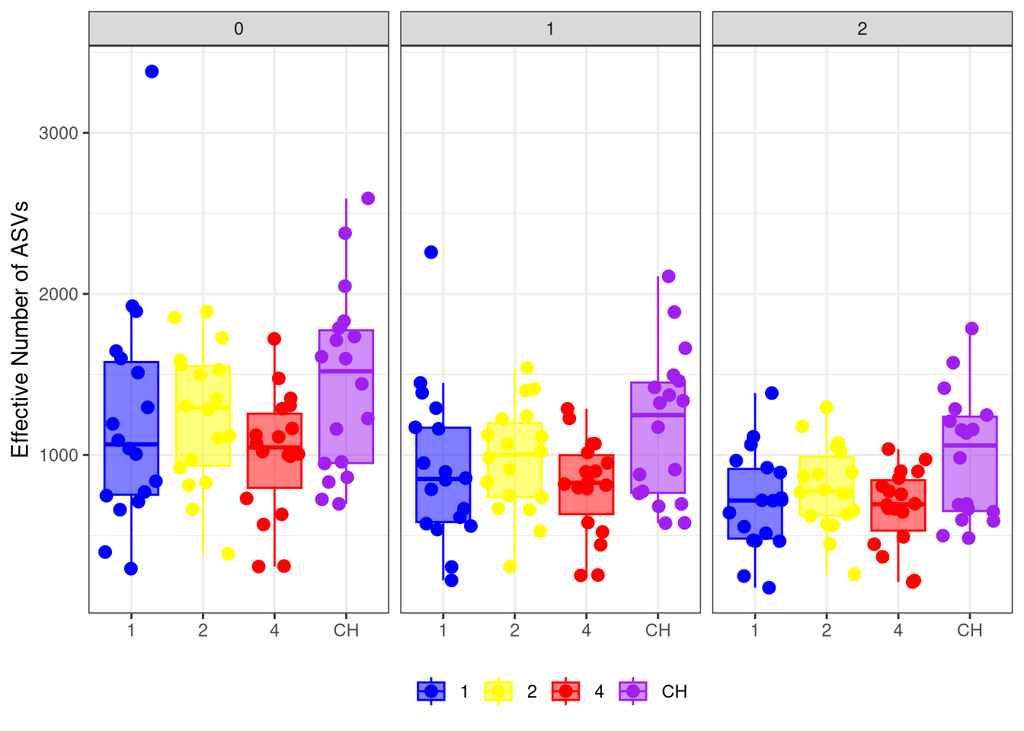

```r
#make a boxplot by the burn year
by_obs_div_df %>%
  ggplot(aes(x = burnyears, y = qD, fill = burn_year, color = burn_year)) +
  facet_wrap(~Order.q, scales = "fixed") +
  geom_jitter(size = 2.5) +
  geom_boxplot(alpha = 0.5, outlier.shape = NA) +
  scale_color_manual(values = burn_year_colors) +
  scale_fill_manual(values = burn_year_colors) +
  labs(y = "Effective Number of ASVs") +
  theme_bw() +
  theme(legend.position = "bottom",
        axis.title.x = element_blank(),
        legend.title = element_blank())
```

Horizon B has the lowest values for each diversity measurement. While horizon A appears to have higher richness and common taxa, horizon E has a slightly higher value for dominant taxa. Overall, the measurements for each of the horizons do not vary by much.

for burn year, there is still nothing too interesting. Although, there appears to be slight increase of the ASVs in the control.

## Environmental variable Check

there aren’t really any environmental variables in the metadata, but looking at depth could be cool since it correlates to horizon

```r
#for some reason, the units are in the rows so this needs to be removed
nocm_iNEXT_manual_df <- iNEXT_manual_df %>%
  dplyr::filter(Method == "Observed") %>%
  mutate(Depth = as.numeric(sub("cm", "", Depth)))

env_df <-
  metadata_df %>%
  dplyr::select(names, Depth:burn_year)
# inspect
head(env_df)
```

```
##                   names Depth elev env_broad_scale env_local_scale
## SRR19625066 SRR19625066  43cm  45m   ENVO_01000174   ENVO_01001582
## SRR19625067 SRR19625067  58cm  45m   ENVO_01000174   ENVO_01001582
## SRR19625068 SRR19625068  28cm  45m   ENVO_01000174   ENVO_01001582
## SRR19625069 SRR19625069  36cm  45m   ENVO_01000174   ENVO_01001582
## SRR19625070 SRR19625070  11cm  45m   ENVO_01000174   ENVO_01001582
## SRR19625071 SRR19625071   8cm  45m   ENVO_01000174   ENVO_01001582
##                              env_medium  Experiment geo_loc_name_country
## SRR19625066 ENVO_00005746 | PCO_1000004 SRX15675757                  USA
## SRR19625067 ENVO_00005746 | PCO_1000004 SRX15675756                  USA
## SRR19625068 ENVO_00005746 | PCO_1000004 SRX15675755                  USA
## SRR19625069 ENVO_00005746 | PCO_1000004 SRX15675754                  USA
## SRR19625070 ENVO_00005746 | PCO_1000004 SRX15675753                  USA
## SRR19625071 ENVO_00005746 | PCO_1000004 SRX15675752                  USA
##             geo_loc_name_country_continent geo_loc_name   horizon
## SRR19625066                  North America USA: Florida E horizon
## SRR19625067                  North America USA: Florida B horizon
## SRR19625068                  North America USA: Florida E horizon
## SRR19625069                  North America USA: Florida B horizon
## SRR19625070                  North America USA: Florida A horizon
## SRR19625071                  North America USA: Florida A horizon
##                 Instrument             lat_lon   Library.Name LibraryLayout
## SRR19625066 Illumina MiSeq 30.1911 N 82.4329 W  1C_E_FLBACPRE        PAIRED
## SRR19625067 Illumina MiSeq 30.1911 N 82.4329 W  1C_B_FLBACPRE        PAIRED
## SRR19625068 Illumina MiSeq 30.1911 N 82.4329 W CHF_E_FLBACPRE        PAIRED
## SRR19625069 Illumina MiSeq 30.1911 N 82.4329 W CHF_B_FLBACPRE        PAIRED
## SRR19625070 Illumina MiSeq 30.1911 N 82.4329 W  1C_A_FLBACPRE        PAIRED
## SRR19625071 Illumina MiSeq 30.1911 N 82.4329 W CHF_A_FLBACPRE        PAIRED
##             LibrarySelection LibrarySource        Organism Platform
## SRR19625066              PCR   METAGENOMIC soil metagenome ILLUMINA
## SRR19625067              PCR   METAGENOMIC soil metagenome ILLUMINA
## SRR19625068              PCR   METAGENOMIC soil metagenome ILLUMINA
## SRR19625069              PCR   METAGENOMIC soil metagenome ILLUMINA
## SRR19625070              PCR   METAGENOMIC soil metagenome ILLUMINA
## SRR19625071              PCR   METAGENOMIC soil metagenome ILLUMINA
##               ReleaseDate replicate   create_date version    Sample.Name
## SRR19625066 6/11/22 20:00        NO 6/12/22 18:38       1  1C_E_FLBACPRE
## SRR19625067 6/11/22 20:00        NO 6/12/22 18:39       1  1C_B_FLBACPRE
## SRR19625068 6/11/22 20:00        NO 6/12/22 18:38       1 CHF_E_FLBACPRE
## SRR19625069 6/11/22 20:00        NO 6/12/22 18:38       1 CHF_B_FLBACPRE
## SRR19625070 6/11/22 20:00        NO 6/12/22 18:38       1  1C_A_FLBACPRE
## SRR19625071 6/11/22 20:00        NO 6/12/22 18:38       1 CHF_A_FLBACPRE
##             burn_year
## SRR19625066         1
## SRR19625067         1
## SRR19625068        CH
## SRR19625069        CH
## SRR19625070         1
## SRR19625071        CH
```

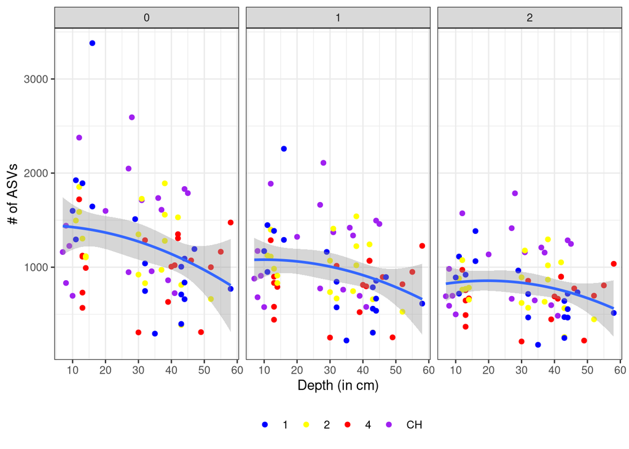

```r
nocm_iNEXT_manual_df %>%
  dplyr::filter(Method == "Observed") %>%
  ggplot(aes(x = Depth, y = qD)) +
  facet_wrap(.~Order.q, scales = "fixed") +
  geom_point(aes(color = burn_year)) +
  stat_smooth(method = "lm", formula = y ~poly(x, 2)) +
  labs(x = "Depth (in cm)", y = "# of ASVs") +
  scale_color_manual(values = burn_year_colors) +
  theme_bw() +
  theme(legend.position = "bottom",
        legend.title = element_blank())
```

it seems that with the increase in depth, diversity also drops. However, with year 4, there seems to be a slight increase in depth, but this could just be due to outliers present.